# Analiza skupa podataka o kretanju taksi vozila u Njujorku u januaru 2015. godine

Luka Ćirić

### Luka Ćirić, E2 18/2023

# Specifikacija

Specifikacija na [linku](http://www.acs.uns.ac.rs/sr/filebrowser/download/11975528)

# Opis skupa podataka

Skup podataka je javno dostupan za preuzimanje na [linku](https://www.nyc.gov/site/tlc/about/tlc-trip-record-data.page). Podaci originalno preuzeti u **PARQUET** formatu, a zatim konvertovani u **CSV** format. Skup podataka se sastoji od podataka o kretanju taksi vozila i zaradi u Njujorku u januaru 2015. godine.

## Opis atributa

Skup podataka se sastoji od atributa:  
1. **VendorID** - identifikator provajdera usluge taksi prevoza  
2. **tpep_pickup_datetime** - datum i vreme preuzimanja putnika  
3. **tpep_dropoff_datetime** - datum i vreme iskrcavanja putnika  
4. **passenger_count** - broj putnika  
5. **trip_distance** - dužina putovanja u miljama  
6. **RatecodeID** - identifikator tarifnog koda  
7. **store_and_fwd_flag** - indikator da li je vožnja prvo sačuvana u memoriji pre slanja  
8. **PULocationID** - identifikator lokacije preuzimanja putnika  
9. **DOLocationID** - identifikator lokacije iskrcavanja putnika  
10. **payment_type** - način plaćanja  
12. **fare_amount** - cena vožnje  
13. **extra** - dodatni troškovi  
14. **mta_tax** - troškovi MTA  
15. **tip_amount** - napojnica (popunjena samo za plaćanje karticom)  
16. **tolls_amount** - troškovi putarine  
17. **improvement_surcharge** - troškovi poboljšanja  
18. **total_amount** - ukupna cena  
19. **congestion_surcharge** - troškovi gužve  
20. **airport_fee** - troškovi aerodroma

Specifikacija obeležja dostupna na [linku](https://www.nyc.gov/assets/tlc/downloads/pdf/data_dictionary_trip_records_yellow.pdf)

## Kod za prevođenje podataka u CSV format (Python):

```python
import pandas as pd

def parquet_to_csv(parquet_file_path, csv_file_path):
    # Read the Parquet file into a DataFrame
    df = pd.read_parquet(parquet_file_path)

    # Write the DataFrame to a CSV file
    df.to_csv(csv_file_path, index=False)

if __name__ == "__main__":
    # Replace these with your actual file paths
    parquet_file_path = input("Enter input file: ") + ".parquet"
    csv_file_path = input("Enter output file: ") + ".csv"

    parquet_to_csv(parquet_file_path, csv_file_path)
```

# Implementacija

Implementacija radjena u **R** programskom jeziku, korišćenjem **R Markdown** dokumenta. ## Instalacija ### Instalacija paketa

```r
install.packages("tidyverse")
install.packages("sparklyr")
install.packages("rmarkdown")
install.packages("knitr")
install.packages("pandoc")
install.packages("dbplot")
install.packages("ggcorrplot")
```

### Učitavanje paketa

```r
library(sparklyr)
library(dplyr)
library(knitr)
library(rmarkdown)
library(ggplot2)
library(ggcorrplot)
library(dbplot)
library(pandoc)
spark_install()
knitr::opts_knit$set(root.dir = file.path(getwd()))
```

### Podešavanje Spark sesije

```r
conf <- spark_config()
conf["spark.memory.fraction"] <- 0.9
conf["sparklyr.shell.driver-memory"] <- "16G"
sc <- spark_connect(master = "local", config = conf)
```

## Podaci

### Učitavanje skupa podataka

```r
ds.path <- "~/FAX/RVPUII/projekat/data"
ds.df <- spark_read_csv(sc, name = "my_data", path = ds.path, header = TRUE, infer_schema = TRUE, memory = TRUE)
```

### Filtriranje skupa podataka

```r
ds.filtered <- ds.df %>%
    select(passenger_count, trip_distance, payment_type, fare_amount, tip_amount, tolls_amount, total_amount) %>%
    filter(
      !(is.na(passenger_count) || is.na(trip_distance) || is.na(payment_type) ||
        is.na(fare_amount) || is.na(total_amount) || is.na(tip_amount) || is.na(tolls_amount))
    ) %>%
    filter(
        trip_distance >= 0 && trip_distance <= 200 &&
        fare_amount >= 0 && fare_amount <= 1000 &&
        tip_amount >= 0 && tip_amount <= 200 &&
        tolls_amount >= 0 && tolls_amount <= 200 &&
        total_amount >= 0 && total_amount <= 1000 &&
        payment_type >= 1 && payment_type <= 6 &&
        passenger_count >= 1 && passenger_count <= 8
    )
```

### Dodavanje novih atributa

```r
data <- ds.filtered %>%
    mutate(tip_status = cut(
        tip_amount,
        breaks = c(0, 1, 5, 10, Inf),
        labels = c("NONE", "LOW", "MID", "HIGH"),
        right = FALSE
    ))
```

### Funkcija za čišćenje memorije

```r
clearFn <- function() {
    all_objects <- ls()
    needed_to_keep <- c("sc", "ds.df", "ds.filtered", "data", "conf", "clearFn")
    to_remove <- setdiff(all_objects, needed_to_keep)
    rm(list = to_remove)
}
```

## Analiza pojedinačnih atributa

### Analiza atributa passenger_count

```r
passengerCountCounts <- data %>%
    group_by(passenger_count) %>%
    summarise(count = n()) %>%
    collect() %>% arrange(passenger_count)

kable(passengerCountCounts)
```

| passenger_count | count |
| --- | --- |
| 1 | 8984540 |
| 2 | 1813233 |
| 3 | 528044 |
| 4 | 253010 |
| 5 | 697121 |
| 6 | 454295 |
| 7 | 9 |
| 8 | 10 |

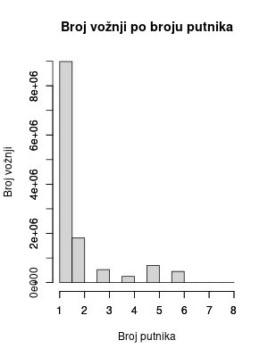

Broj vožnji po broju putnika

### Analiza atributa trip_distance

```r
tripDistanceCounts <- data %>%
    summarise(min = min(trip_distance), max = max(trip_distance), avg = mean(trip_distance), median = median(trip_distance)) %>%
    collect()

kable(tripDistanceCounts)
```

| min | max | avg | median |
| --- | --- | --- | --- |
| 0 | 198.5 | 2.786259 | 1.68 |

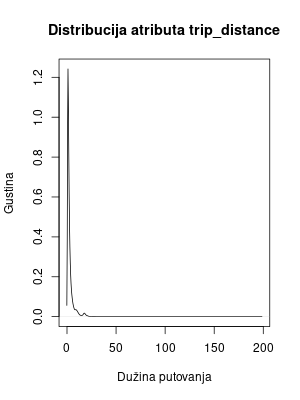

Distribucija atributa trip_distance

### Analiza atributa payment_type

```r
paymentTypeCounts <- data %>%
    group_by(payment_type) %>%
    summarise(count = n()) %>%
    collect() %>% arrange(payment_type)

kable(paymentTypeCounts)
```

| payment_type | count |
| --- | --- |
| 1 | 7875180 |
| 2 | 4808204 |
| 3 | 36855 |
| 4 | 10021 |
| 5 | 2 |

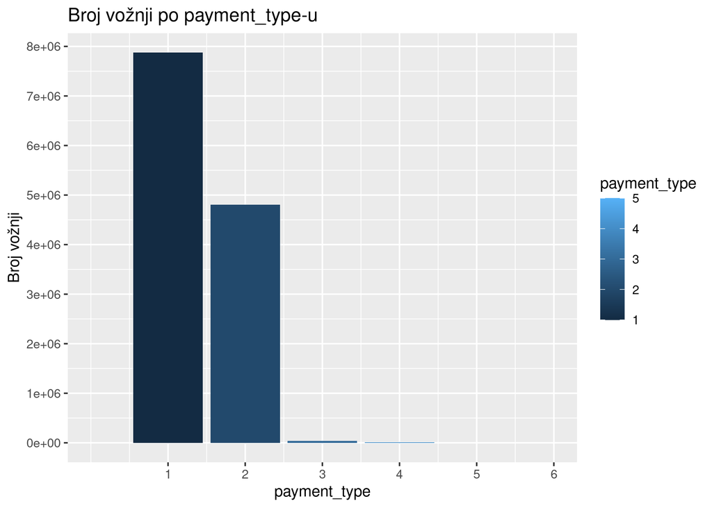

Broj vožnji po payment_type-u

### Analiza atributa fare_amount

```r
fareAmountCounts <- data %>%
    summarise(min = min(fare_amount), max = max(fare_amount), avg = mean(fare_amount), median = median(fare_amount)) %>%
    collect()


kable(fareAmountCounts)
```

| min | max | avg | median |
| --- | --- | --- | --- |
| 0 | 980 | 11.91094 | 9 |

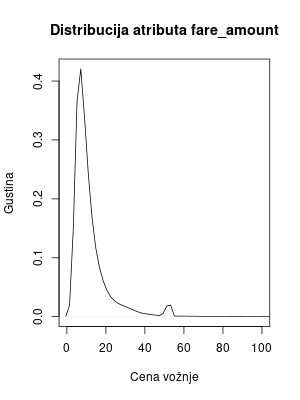

Distribucija atributa fare_amount

### Analiza atributa tip_amount

```r
tipAmountCounts <- data %>%
    summarise(min = min(tip_amount), max = max(tip_amount), avg = mean(tip_amount), median = median(tip_amount)) %>%
    collect()


kable(tipAmountCounts)
```

| min | max | avg | median |
| --- | --- | --- | --- |
| 0 | 200 | 1.544106 | 1 |

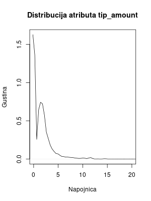

Distribucija atributa tip_amount

### Analiza atributa tolls_amount

```r
tollsAmountCounts <- data %>%
    summarise(min = min(tolls_amount), max = max(tolls_amount), avg = mean(tolls_amount), median = median(tolls_amount)) %>%
    collect()


kable(tollsAmountCounts)
```

| min | max | avg | median |
| --- | --- | --- | --- |
| 0 | 185.33 | 0.2426916 | 0 |

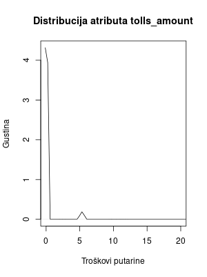

Distribucija atributa tolls_amount

### Analiza atributa total_amount

```r
totalAmountCounts <- data %>%
    summarise(min = min(total_amount), max = max(total_amount), avg = mean(total_amount), median = median(total_amount)) %>%
    collect()

kable(totalAmountCounts)
```

| min | max | avg | median |
| --- | --- | --- | --- |
| 0 | 980.3 | 14.80387 | 11.16 |

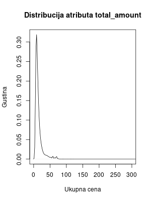

Distribucija atributa total_amount

### Analiza atributa tip_status

```r
tipStatusCounts <- data %>%
    group_by(tip_status) %>%
    summarise(count = n()) %>%
    collect()

kable(tipStatusCounts)
```

| tip_status | count |
| --- | --- |
| LOW | 6623862 |
| MID | 542327 |
| NONE | 5373838 |
| HIGH | 190235 |

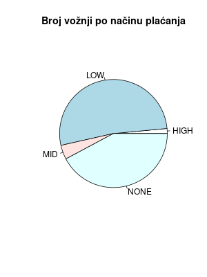

Broj vožnji po načinu plaćanja

## Analiza zavisnosti atributa

### Analiza zavisnosti atributa passenger_count i trip_distance

```r
passengerCountTripDistance <- data %>%
    group_by(passenger_count) %>%
    summarise(min = min(trip_distance), max = max(trip_distance), avg = mean(trip_distance), median = median(trip_distance)) %>%
    collect()

kable(passengerCountTripDistance)
```

| passenger_count | min | max | avg | median |
| --- | --- | --- | --- | --- |
| 5 | 0 | 94.16 | 2.858132 | 1.70 |
| 1 | 0 | 198.50 | 2.739670 | 1.64 |
| 3 | 0 | 169.00 | 2.851900 | 1.70 |
| 2 | 0 | 188.60 | 2.957529 | 1.70 |
| 6 | 0 | 51.61 | 2.789894 | 1.68 |
| 7 | 0 | 8.40 | 2.566667 | 1.40 |
| 4 | 0 | 177.80 | 2.871700 | 1.71 |
| 8 | 0 | 17.39 | 2.179000 | 0.00 |

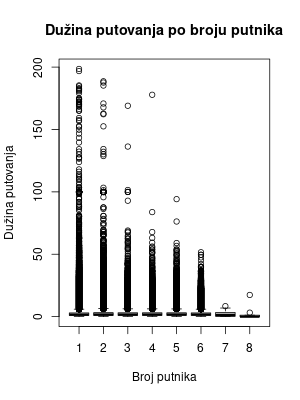

Dužina putovanja po broju putnika

### Analiza zavisnosti atributa passenger_count i payment_type

```r
passengerCountPaymentType <- data %>%
    group_by(passenger_count, payment_type) %>%
    summarise(count = n()) %>%
    collect() %>% arrange(passenger_count, payment_type)

kable(passengerCountPaymentType)
```

| passenger_count | payment_type | count |
| --- | --- | --- |
| 1 | 1 | 5635040 |
| 1 | 2 | 3309726 |
| 1 | 3 | 31438 |
| 1 | 4 | 8335 |
| 1 | 5 | 1 |
| 2 | 1 | 1084231 |
| 2 | 2 | 724203 |
| 2 | 3 | 3660 |
| 2 | 4 | 1139 |
| 3 | 1 | 305605 |
| 3 | 2 | 221154 |
| 3 | 3 | 978 |
| 3 | 4 | 306 |
| 3 | 5 | 1 |
| 4 | 1 | 134846 |
| 4 | 2 | 117231 |
| 4 | 3 | 708 |
| 4 | 4 | 225 |
| 5 | 1 | 434787 |
| 5 | 2 | 262278 |
| 5 | 3 | 42 |
| 5 | 4 | 14 |
| 6 | 1 | 280656 |
| 6 | 2 | 173609 |
| 6 | 3 | 28 |
| 6 | 4 | 2 |
| 7 | 1 | 7 |
| 7 | 2 | 2 |
| 8 | 1 | 8 |
| 8 | 2 | 1 |
| 8 | 3 | 1 |

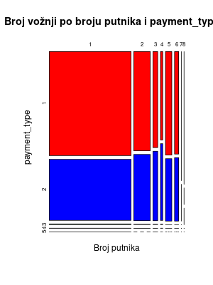

Broj vožnji po broju putnika i payment_type-u

### Analiza zavisnosti atributa passenger_count i fare_amount

```r
passengerCountFareAmount <- data %>%
    group_by(passenger_count) %>%
    summarise(min = min(fare_amount), max = max(fare_amount), avg = mean(fare_amount), median = median(fare_amount)) %>%
    collect()

kable(passengerCountFareAmount)
```

| passenger_count | min | max | avg | median |
| --- | --- | --- | --- | --- |
| 5 | 0.0 | 234.0 | 11.97525 | 9.0 |
| 1 | 0.0 | 980.0 | 11.78523 | 9.0 |
| 3 | 0.0 | 525.0 | 12.13394 | 9.0 |
| 2 | 0.0 | 900.0 | 12.42997 | 9.0 |
| 6 | 0.0 | 186.5 | 11.80656 | 9.0 |
| 7 | 3.0 | 24.5 | 11.25556 | 7.5 |
| 4 | 0.0 | 780.0 | 12.19905 | 9.0 |
| 8 | 2.5 | 80.0 | 29.58000 | 8.4 |

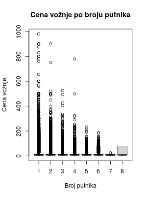

Cena vožnje po broju putnika

### Analiza zavisnosti atributa passenger_count i tip_amount

```r
passengerCountTipAmount <- data %>%
    group_by(passenger_count) %>%
    summarise(min = min(tip_amount), max = max(tip_amount), avg = mean(tip_amount), median = median(tip_amount)) %>%
    collect()

kable(passengerCountTipAmount)
```

| passenger_count | min | max | avg | median |
| --- | --- | --- | --- | --- |
| 5 | 0 | 160.00 | 1.542839 | 1.00 |
| 1 | 0 | 200.00 | 1.558885 | 1.05 |
| 3 | 0 | 133.04 | 1.440956 | 1.00 |
| 2 | 0 | 167.00 | 1.541044 | 1.00 |
| 6 | 0 | 200.00 | 1.504345 | 1.00 |
| 7 | 0 | 5.05 | 2.088889 | 1.90 |
| 4 | 0 | 110.00 | 1.331389 | 0.90 |
| 8 | 0 | 3.05 | 1.209000 | 1.30 |

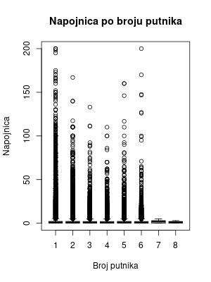

Napojnica po broju putnika

### Analiza zavisnosti atributa passenger_count i tolls_amount

```r
passengerCountTollsAmount <- data %>%
    group_by(passenger_count) %>%
    summarise(min = min(tolls_amount), max = max(tolls_amount), avg = mean(tolls_amount), median = median(tolls_amount)) %>%
    collect()

kable(passengerCountTollsAmount)
```

| passenger_count | min | max | avg | median |
| --- | --- | --- | --- | --- |
| 5 | 0 | 41.44 | 0.2581405 | 0 |
| 1 | 0 | 185.33 | 0.2293901 | 0 |
| 3 | 0 | 144.00 | 0.2570367 | 0 |
| 2 | 0 | 127.66 | 0.2960527 | 0 |
| 6 | 0 | 35.25 | 0.2397368 | 0 |
| 7 | 0 | 5.33 | 0.5922222 | 0 |
| 4 | 0 | 120.08 | 0.2653747 | 0 |
| 8 | 0 | 9.75 | 0.9750000 | 0 |

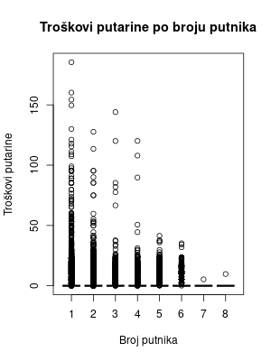

Troškovi putarine po broju putnika

### Analiza zavisnosti atributa passenger_count i total_amount

```r
passengerCountTotalAmount <- data %>%
    group_by(passenger_count) %>%
    summarise(min = min(total_amount), max = max(total_amount), avg = mean(total_amount), median = median(total_amount)) %>%
    collect()

kable(passengerCountTotalAmount)
```

| passenger_count | min | max | avg | median |
| --- | --- | --- | --- | --- |
| 5 | 0.0 | 247.38 | 14.88832 | 11.30 |
| 1 | 0.0 | 980.30 | 14.67572 | 11.15 |
| 3 | 0.0 | 600.30 | 14.95944 | 11.30 |
| 2 | 0.0 | 900.30 | 15.38612 | 11.30 |
| 6 | 0.0 | 273.07 | 14.63924 | 11.00 |
| 7 | 4.3 | 36.13 | 15.18111 | 11.15 |
| 4 | 0.0 | 780.30 | 14.91918 | 11.30 |
| 8 | 3.8 | 90.05 | 32.46400 | 11.52 |

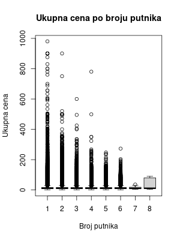

Ukupna cena po broju putnika

### Analiza zavisnosti atributa passenger_count i tip_status

```r
passengerCountTipStatus <- data %>%
    group_by(passenger_count, tip_status) %>%
    summarise(count = n()) %>%
    collect()

kable(passengerCountTipStatus)
```

| passenger_count | tip_status | count |
| --- | --- | --- |
| 5 | LOW | 359891 |
| 6 | HIGH | 6489 |
| 3 | LOW | 256380 |
| 5 | HIGH | 10639 |
| 7 | NONE | 3 |
| 2 | LOW | 903585 |
| 1 | MID | 381807 |
| 6 | NONE | 196098 |
| 3 | MID | 20955 |
| 5 | MID | 30783 |
| 1 | LOW | 4758484 |
| 2 | HIGH | 30026 |
| 4 | HIGH | 3112 |
| 5 | NONE | 295808 |
| 4 | MID | 9429 |
| 3 | HIGH | 7125 |
| 2 | MID | 80473 |
| 7 | LOW | 4 |
| 6 | MID | 18878 |
| 1 | NONE | 3711405 |
| 2 | NONE | 799149 |
| 3 | NONE | 243584 |
| 6 | LOW | 232830 |
| 1 | HIGH | 132844 |
| 4 | NONE | 127787 |
| 4 | LOW | 112682 |
| 8 | LOW | 6 |
| 8 | NONE | 4 |
| 7 | MID | 2 |

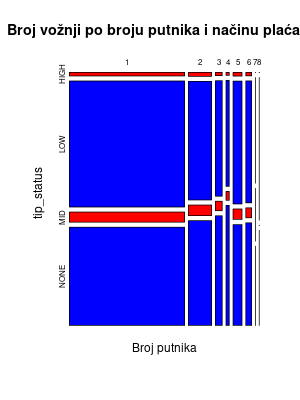

Broj vožnji po broju putnika i načinu plaćanja

### Analiza zavisnosti atributa trip_distance i payment_type

```r
tripDistancePaymentType <- data %>%
    group_by(payment_type) %>%
    summarise(min = min(trip_distance), max = max(trip_distance), avg = mean(trip_distance), median = median(trip_distance)) %>%
    collect()
```

### Analiza zavisnosti atributa trip_distance i fare_amount

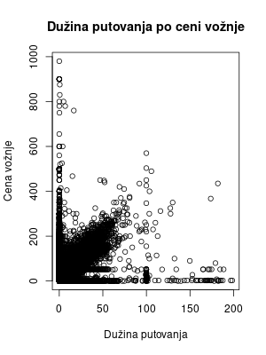

Dužina putovanja po ceni vožnje

### Analiza zavisnosti atributa trip_distance i tip_amount

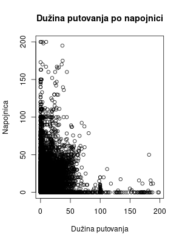

Dužina putovanja po napojnici

### Analiza zavisnosti atributa trip_distance i tolls_amount

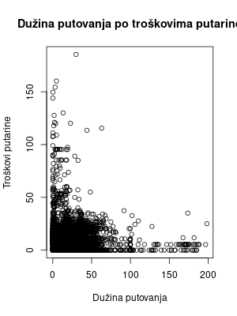

Dužina putovanja po troškovima putarine

### Analiza zavisnosti atributa trip_distance i total_amount

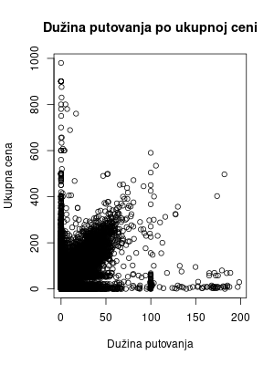

Dužina putovanja po ukupnoj ceni

### Analiza zavisnosti atributa trip_distance i tip_status

```r
tripDistanceTipStatus <- data %>%
    group_by(tip_status) %>%
    summarise(min = min(trip_distance), max = max(trip_distance), avg = mean(trip_distance), median = median(trip_distance)) %>%
    collect()

kable(tripDistanceTipStatus)
```

| tip_status | min | max | avg | median |
| --- | --- | --- | --- | --- |
| LOW | 0 | 180.6 | 2.150941 | 1.70 |
| MID | 0 | 149.8 | 9.130406 | 8.94 |
| NONE | 0 | 198.5 | 2.480372 | 1.42 |
| HIGH | 0 | 188.6 | 15.462410 | 17.24 |

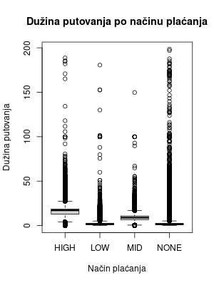

Dužina putovanja po načinu plaćanja

### Analiza zavisnosti atributa payment_type i fare_amount

```r
paymentTypeFareAmount <- data %>%
    group_by(payment_type) %>%
    summarise(min = min(fare_amount), max = max(fare_amount), avg = mean(fare_amount), median = median(fare_amount)) %>%
    collect()

kable(paymentTypeFareAmount)
```

| payment_type | min | max | avg | median |
| --- | --- | --- | --- | --- |
| 1 | 0 | 980.00 | 12.49501 | 9.5 |
| 3 | 0 | 760.01 | 11.18823 | 6.0 |
| 2 | 0 | 800.00 | 10.95722 | 8.0 |
| 4 | 0 | 875.50 | 13.17419 | 7.5 |
| 5 | 0 | 6.00 | 3.00000 | 3.0 |

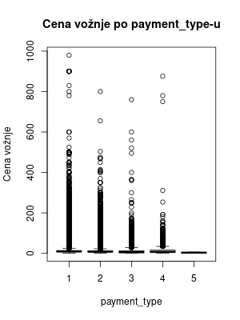

Cena vožnje po payment_type-u

### Analiza zavisnosti atributa payment_type i tip_amount

```r
paymentTypeTipAmount <- data %>%
    group_by(payment_type) %>%
    summarise(min = min(tip_amount), max = max(tip_amount), avg = mean(tip_amount), median = median(tip_amount)) %>%
    collect()

kable(paymentTypeTipAmount)
```

| payment_type | min | max | avg | median |
| --- | --- | --- | --- | --- |
| 1 | 0 | 200.00 | 2.4959061 | 1.95 |
| 3 | 0 | 24.00 | 0.0029214 | 0.00 |
| 2 | 0 | 50.06 | 0.0002140 | 0.00 |
| 4 | 0 | 5.55 | 0.0022223 | 0.00 |
| 5 | 0 | 0.00 | 0.0000000 | 0.00 |

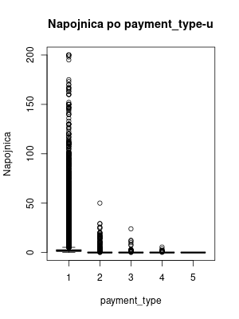

Napojnica po payment_type-u

### Analiza zavisnosti atributa payment_type i tolls_amount

```r
paymentTypeTollsAmount <- data %>%
    group_by(payment_type) %>%
    summarise(min = min(tolls_amount), max = max(tolls_amount), avg = mean(tolls_amount), median = median(tolls_amount)) %>%
    collect()

kable(paymentTypeTollsAmount)
```

| payment_type | min | max | avg | median |
| --- | --- | --- | --- | --- |
| 1 | 0 | 185.33 | 0.2853524 | 0 |
| 3 | 0 | 154.33 | 0.3646452 | 0 |
| 2 | 0 | 160.17 | 0.1715250 | 0 |
| 4 | 0 | 121.07 | 0.4151123 | 0 |
| 5 | 0 | 0.00 | 0.0000000 | 0 |

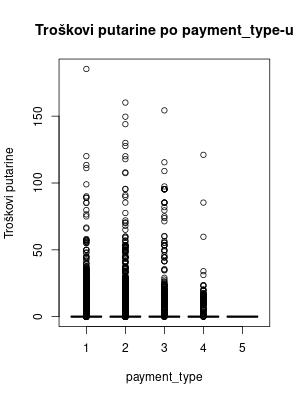

Troškovi putarine po payment_type-u

### Analiza zavisnosti atributa payment_type i total_amount

```r
paymentTypeTotalAmount <- data %>%
    group_by(payment_type) %>%
    summarise(min = min(total_amount), max = max(total_amount), avg = mean(total_amount), median = median(total_amount)) %>%
    collect()

kable(paymentTypeTotalAmount)
```

| payment_type | min | max | avg | median |
| --- | --- | --- | --- | --- |
| 1 | 0.00 | 980.30 | 16.38901 | 12.3 |
| 3 | 0.00 | 760.31 | 12.66946 | 7.3 |
| 2 | 0.00 | 800.30 | 12.22428 | 9.3 |
| 4 | 0.01 | 875.80 | 14.66335 | 8.8 |
| 5 | 0.00 | 6.80 | 3.40000 | 3.4 |

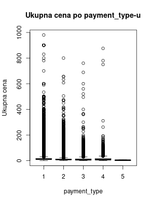

Ukupna cena po payment_type-u

### Analiza zavisnosti atributa payment_type i tip_status

```r
paymentTypeTipStatus <- data %>%
    group_by(payment_type, tip_status) %>%
    summarise(count = n()) %>%
    collect()

kable(paymentTypeTipStatus)
```

| payment_type | tip_status | count |
| --- | --- | --- |
| 2 | LOW | 125 |
| 1 | MID | 542309 |
| 1 | LOW | 6623711 |
| 2 | MID | 15 |
| 3 | NONE | 36831 |
| 2 | NONE | 4808027 |
| 1 | NONE | 518966 |
| 1 | HIGH | 190194 |
| 4 | NONE | 10012 |
| 4 | LOW | 8 |
| 3 | LOW | 18 |
| 3 | MID | 2 |
| 2 | HIGH | 37 |
| 4 | MID | 1 |
| 5 | NONE | 2 |
| 3 | HIGH | 4 |

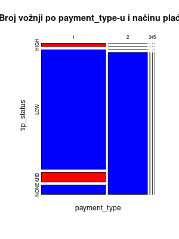

Broj vožnji po payment_type-u i načinu plaćanja

### Analiza zavisnosti atributa fare_amount i tip_amount

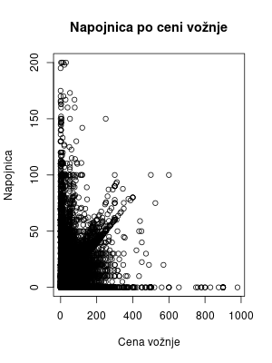

Napojnica po ceni vožnje

### Analiza zavisnosti atributa fare_amount i tolls_amount

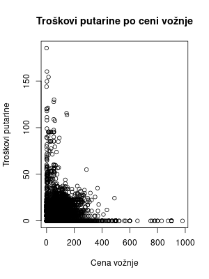

Troškovi putarine po ceni vožnje

### Analiza zavisnosti atributa fare_amount i total_amount

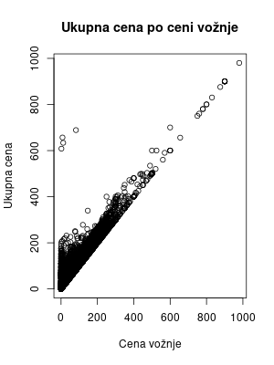

Ukupna cena po ceni vožnje

### Analiza zavisnosti atributa fare_amount i tip_status

```r
fareAmountTipStatus <- data %>%
    group_by(tip_status) %>%
    summarise(min = min(fare_amount), max = max(fare_amount), avg = mean(fare_amount), median = median(fare_amount)) %>%
    collect()

kable(fareAmountTipStatus)
```

| tip_status | min | max | avg | median |
| --- | --- | --- | --- | --- |
| LOW | 0 | 217 | 10.12962 | 9.0 |
| MID | 0 | 342 | 29.80094 | 28.5 |
| NONE | 0 | 980 | 10.93651 | 8.0 |
| HIGH | 0 | 600 | 50.46000 | 52.0 |

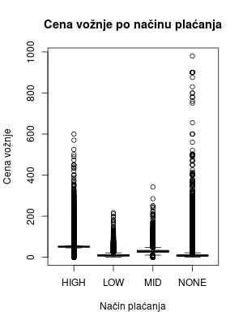

### Analiza zavisnosti atributa tip_amount i tolls_amount

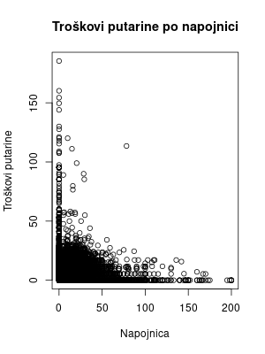

Troškovi putarine po napojnici

### Analiza zavisnosti atributa tip_amount i total_amount

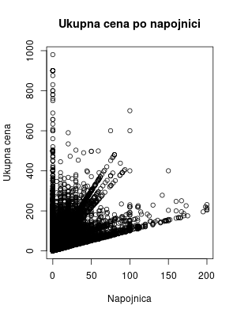

Ukupna cena po napojnici

### Analiza zavisnosti atributa tip_amount i tip_status

```r
tipAmountTipStatus <- data %>%
    group_by(tip_status) %>%
    summarise(min = min(tip_amount), max = max(tip_amount), avg = mean(tip_amount), median = median(tip_amount)) %>%
    collect()

kable(tipAmountTipStatus)
```

| tip_status | min | max | avg | median |
| --- | --- | --- | --- | --- |
| LOW | 1 | 4.99 | 2.0317455 | 1.88 |
| MID | 5 | 9.99 | 6.5812468 | 6.30 |
| NONE | 0 | 0.99 | 0.0328473 | 0.00 |
| HIGH | 10 | 200.00 | 12.8954328 | 11.60 |

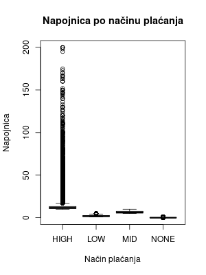

Napojnica po načinu plaćanja

### Analiza zavisnosti atributa tolls_amount i total_amount

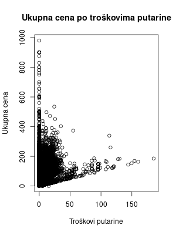

Ukupna cena po troškovima putarine

### Analiza zavisnosti atributa tolls_amount i tip_status

```r
tollsAmountTipStatus <- data %>%
    group_by(tip_status) %>%
    summarise(min = min(tolls_amount), max = max(tolls_amount), avg = mean(tolls_amount), median = median(tolls_amount)) %>%
    collect()

kable(tollsAmountTipStatus)
```

| tip_status | min | max | avg | median |
| --- | --- | --- | --- | --- |
| LOW | 0 | 30.00 | 0.0317082 | 0.00 |
| MID | 0 | 89.00 | 2.0691048 | 0.00 |
| NONE | 0 | 185.33 | 0.1780653 | 0.00 |
| HIGH | 0 | 120.08 | 4.2078035 | 5.33 |

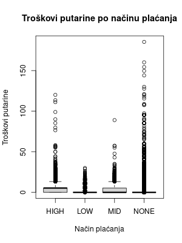

Troškovi putarine po načinu plaćanja

### Analiza zavisnosti atributa total_amount i tip_status

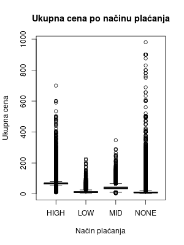

Ukupna cena po načinu plaćanja

### Matrica korelacije

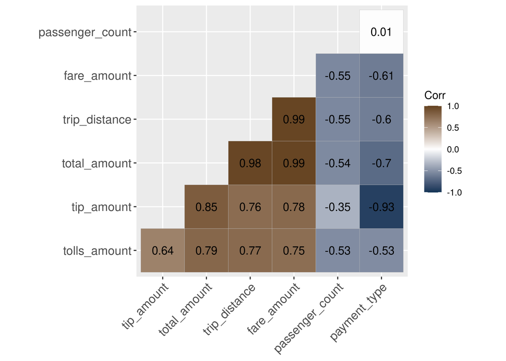

Matrica korelacije

# Klasifikacija

## Priprema podataka

```r
means <- data %>%
    summarise_all(mean) %>%
    collect()

sds <- data %>%
    summarise_all(sd) %>%
    collect()

standardized_data <- data %>%
    mutate(trip_distance = (trip_distance - means$trip_distance) / sds$trip_distance,
           fare_amount = (fare_amount - means$fare_amount) / sds$fare_amount,
           tolls_amount = (tolls_amount - means$tolls_amount) / sds$tolls_amount,
           total_amount = (total_amount - means$total_amount) / sds$total_amount)

split_data <- sdf_random_split(standardized_data, training = 0.8, test = 0.2, seed = 1)
```

### Ciljno obeležje i prediktori

```r
formula <- tip_status ~ trip_distance + fare_amount + tolls_amount + total_amount + passenger_count + payment_type
```

### Funkcija za čišćenje memorije

```r
clearFn <- function() {
    all_objects <- ls()
    needed_to_keep <- c("sc", "ds.df", "ds.filtered", "data", "conf", "clearFn", "split_data", "formula", "standardized_data")
    to_remove <- setdiff(all_objects, needed_to_keep)
    rm(list = to_remove)
}
```

## Logistička regresija

### Obučavanje i evaluacija modela

```r
smp <- c(1:3)
max.iter <- smp * 5

log.precision <- smp
log.recall <- smp
log.fmeasure <- smp
log.accuracy <- smp

for(i in smp){
    model <- ml_logistic_regression(split_data$train, formula, max_iter=max.iter[[i]])
    eval <- ml_evaluate(model, split_data$test)
    log.precision[i] <- eval$weighted_precision()
    log.recall[i] <- eval$weighted_recall()
    log.fmeasure[i] <- eval$weighted_f_measure()
    log.accuracy[i] <- eval$accuracy()
}
```

### Prikaz zavisnosti

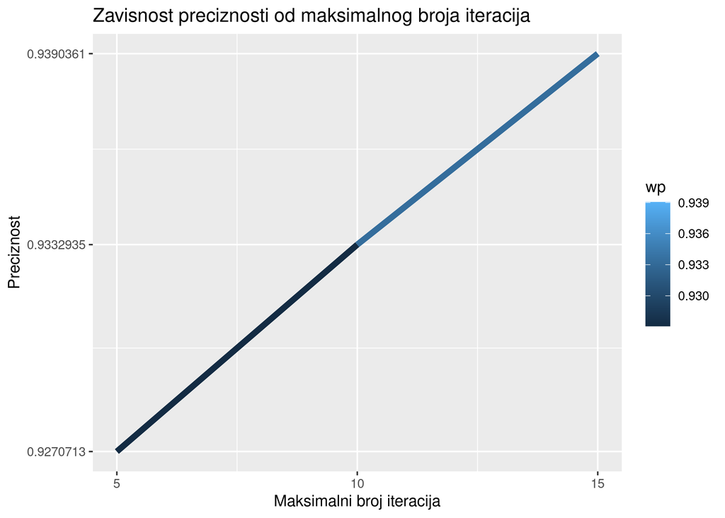

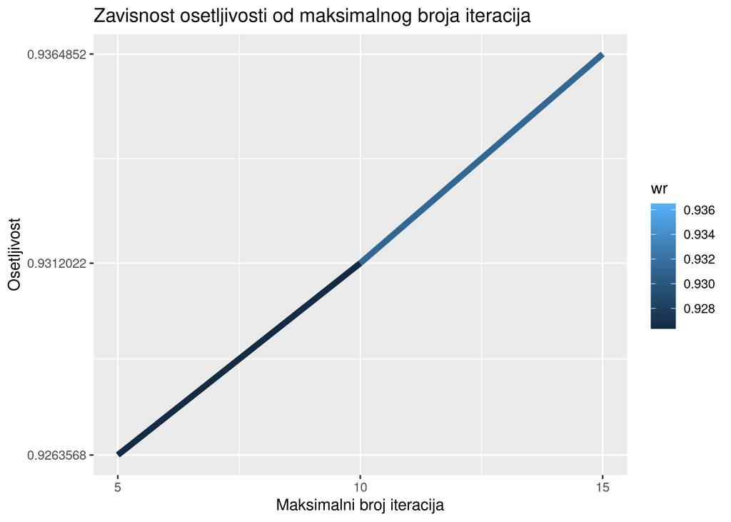

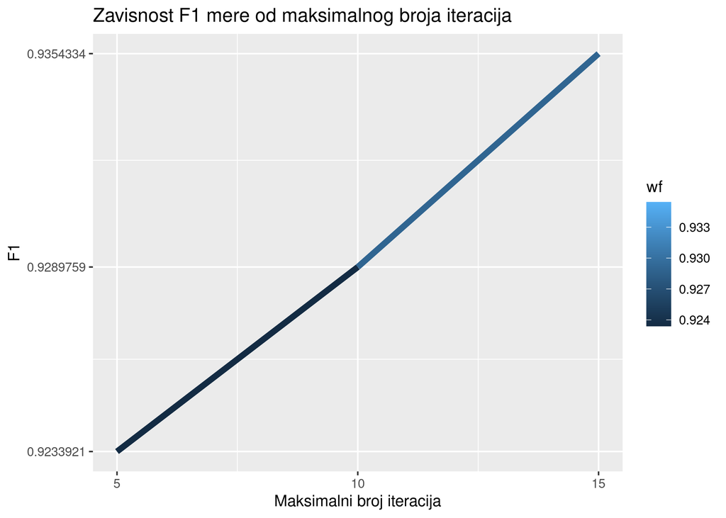

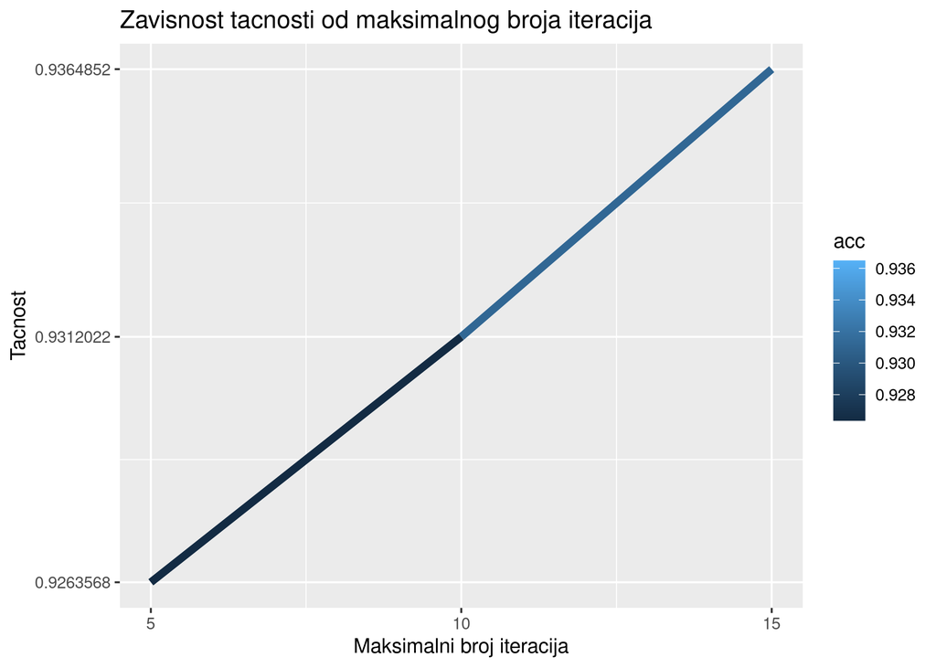

### Validacija

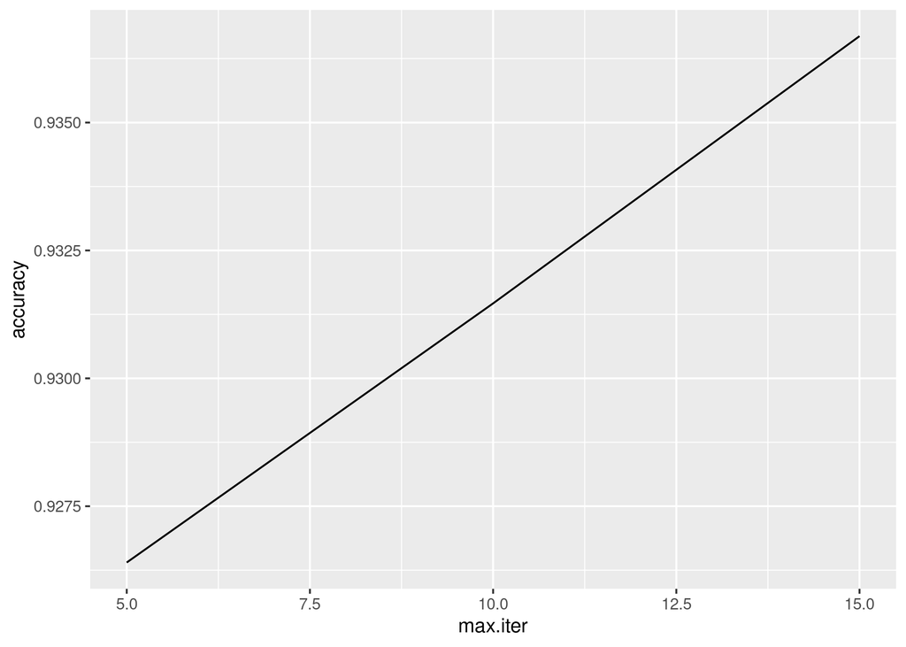

K-folds validacija tacnost logisticka regresija

```r
pip <- sc %>%
    ml_pipeline() %>%
    ft_r_formula(formula) %>%
    ml_logistic_regression()

param_grid <- list(
  logistic_regression = list(max_iter = max.iter)
)

evaluator <- ml_multiclass_classification_evaluator(x=sc, metric_name="accuracy")
validator <- ml_cross_validator(x=sc, estimator=pip, evaluator=evaluator, estimator_param_maps=param_grid, num_folds=4)
fit <- ml_fit(x=validator, dataset=standardized_data)
metrics <- ml_validation_metrics(fit)

p <- metrics %>%
  ggplot(aes(max.iter, accuracy)) +
  geom_line()

ggsave("images/logKFolds.png", p)
```

### Odabir modela

Model sa najviše iteracija pokazao je najbolje rezultate (najbolju preciznost, f1, tačnost, osetljivost) prilikom testiranja i najbolju tačnost prilikom k-fold unakrsnog validiranja sa k=4. Time, biramo model sa 15 iteracija.

## Stablo odlučivanja

### Obučavanje i evaluacija modela

```r
smp <- c(1:3)
max.depth <- smp * 5

dt.accuracy <- smp
dt.sensitivity <- smp
dt.fmeasure <- smp

for(i in smp){
    model <- ml_decision_tree_classifier(split_data$train, formula, max_depth=max.depth[[i]])
    eval <- ml_evaluate(model, split_data$test)

    dt.accuracy[i] <- eval$Accuracy
}
```

### Prikaz zavisnosti

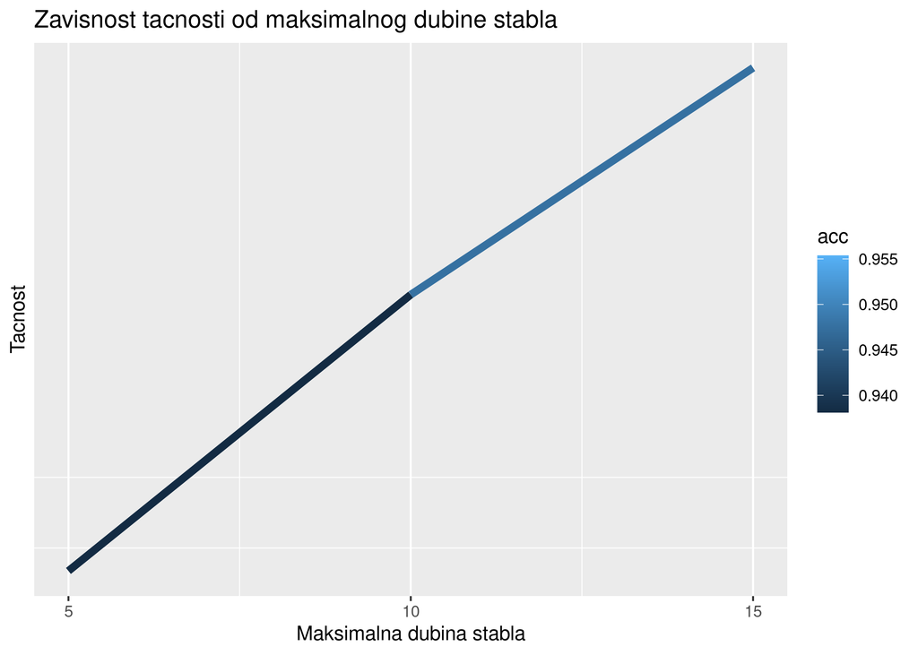

### Validacija

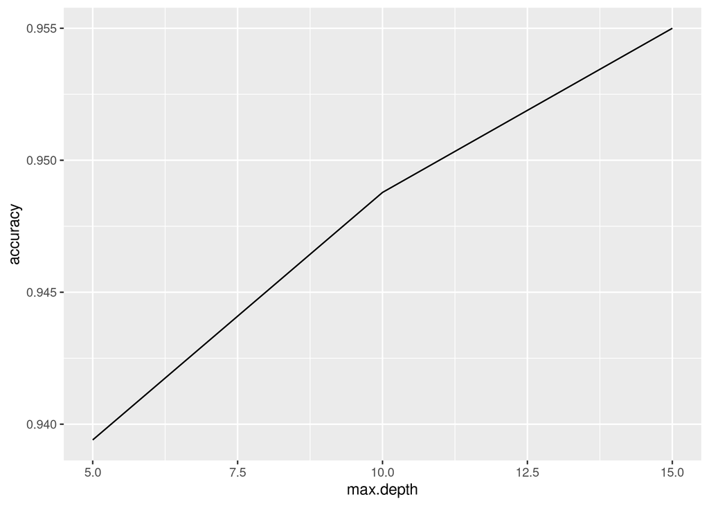

K-folds validacija tacnost stablo odlucivanja

```r
pip <- sc %>%
    ml_pipeline() %>%
    ft_r_formula(formula) %>%
    ml_decision_tree_classifier()

param_grid <- list(
  decision_tree_classifier = list(max_depth = max.depth)
)

evaluator <- ml_multiclass_classification_evaluator(x=sc, metric_name="accuracy")
validator <- ml_cross_validator(x=sc, estimator=pip, evaluator=evaluator, estimator_param_maps=param_grid, num_folds=4)
fit <- ml_fit(x=validator, dataset=standardized_data)
metrics <- ml_validation_metrics(fit)

p <- metrics %>%
  ggplot(aes(max.depth, accuracy)) +
  geom_line()

ggsave("images/dtKFolds.png", p)
```

## Random forest

### Obučavanje i evaluacija modela

```r
smp <- c(1:3)
num.trees <- smp * 5

rf.accuracy <- smp

for(i in smp){
    model <- ml_random_forest_classifier(split_data$train, formula, num_trees=num.trees[[i]])
    eval <- ml_evaluate(model, split_data$test)

    rf.accuracy[i] <- eval$Accuracy
}
```

### Prikaz zavisnosti

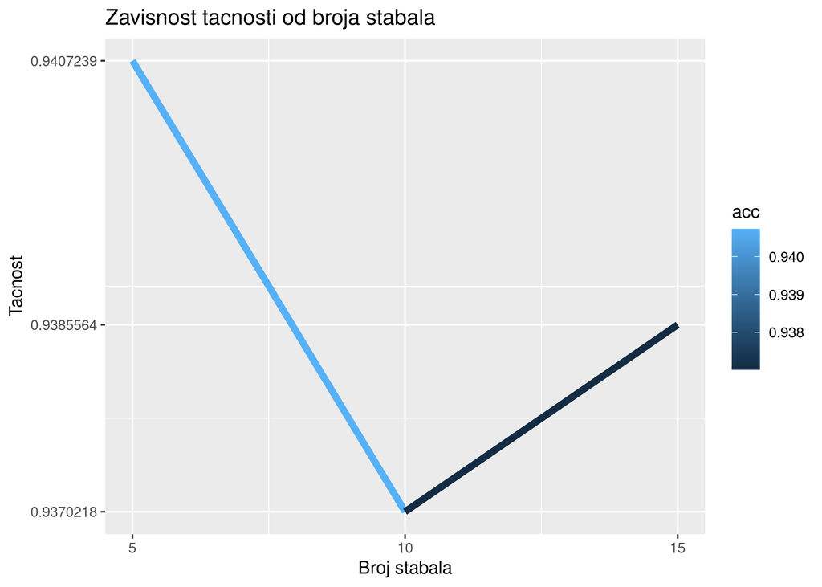

Zavisnost tacnosti od broja stabala

### Validacija

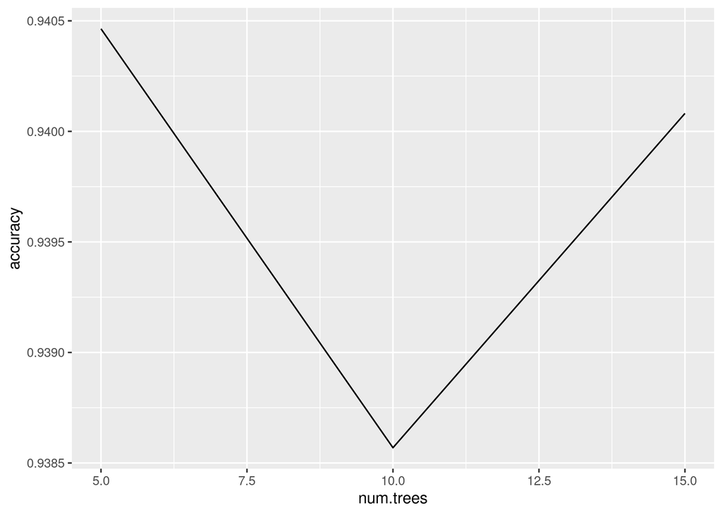

K-folds validacija tacnost random forest

```r
pip <- sc %>%
    ml_pipeline() %>%
    ft_r_formula(formula) %>%
    ml_random_forest_classifier()

param_grid <- list(
    random_forest_classifier = list(num_trees = num.trees)
    )

evaluator <- ml_multiclass_classification_evaluator(x=sc, metric_name="accuracy")
validator <- ml_cross_validator(x=sc, estimator=pip, evaluator=evaluator, estimator_param_maps=param_grid, num_folds=4)
fit <- ml_fit(x=validator, dataset=standardized_data)
metrics <- ml_validation_metrics(fit)

p <- metrics %>%
  ggplot(aes(num.trees, accuracy)) +
  geom_line()

ggsave("images/rfKFolds.png", p)
```

### Odabir modela

Model sa najmanjim brojem stabala pokazao je najbolje tačnost prilikom testiranja i najbolju tačnost prilikom k-fold unakrsnog validiranja sa k=4. Time, biramo model sa 5 stabala.

## Odabir modela od svih

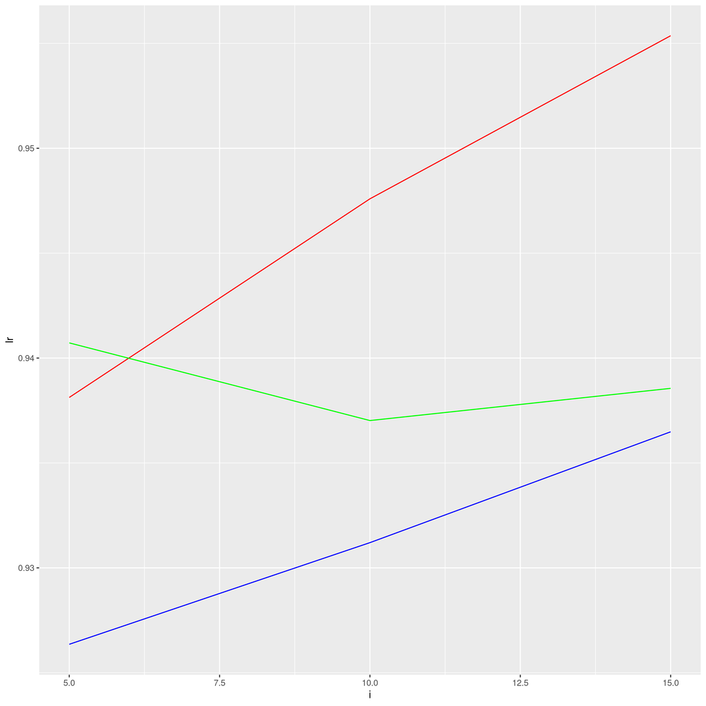

Odabrani model

Odabran je model Stablo odlučivanja sa najvećom dubinom 15 zbog najboljih performansi u vidu tačnosti.

# Klasterizacija

## Priprema podataka

```r
means <- data %>%
    summarise_all(mean) %>%
    collect()

sds <- data %>%
    summarise_all(sd) %>%
    collect()

standardized_data <- data %>%
    select(total_amount, passenger_count, payment_type) %>%
    mutate(passenger_count = (passenger_count - means$passenger_count) / sds$passenger_count,
           payment_type = (payment_type - means$payment_type) / sds$payment_type,
           total_amount = (total_amount - means$total_amount) / sds$total_amount)

features <- standardized_data
formula <- ~ total_amount + passenger_count + payment_type
```

### Funkcija za čišćenje memorije

```r
clearFn <- function() {
    all_objects <- ls()
    needed_to_keep <- c("sc", "ds.df", "ds.filtered", "data", "conf", "clearFn", "features", "standardized_data", "sds", "means", "formula")
    to_remove <- setdiff(all_objects, needed_to_keep)
    rm(list = to_remove)
}
```

## K-means

### Biranje K

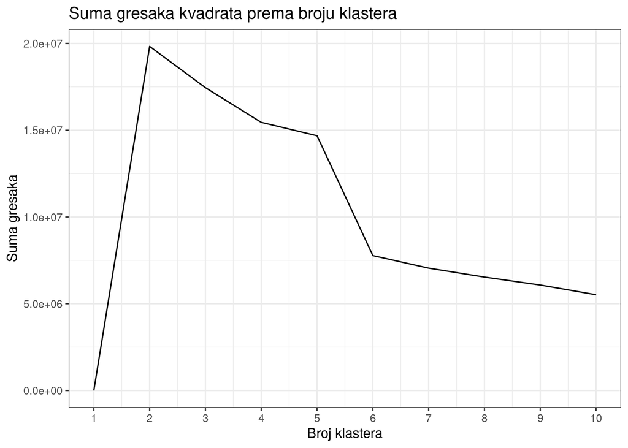

Suma gresaka

```r
clustered <- list()
for(k in 2:10) {
  clustered[[k]] <- features %>% ml_bisecting_kmeans(formula=formula, k = k, max_iter = 10)
}

k_errors <- numeric(10)
for(i in 2:10) {
  k_errors[i] <- clustered[[i]]$cost
}
k_errors_df <- data.frame(i=1:10, e=k_errors)

k_elbow_plot <- ggplot(k_errors_df) +
  geom_line(mapping = aes(x = i, y = e)) +
  scale_x_continuous(breaks = 1:10) +
  labs(title = "Suma gresaka kvadrata prema broju klastera",
       x = "Broj klastera",
       y = "Suma gresaka") +
  theme_bw()
ggsave("images/kElbowPlot.png", k_elbow_plot)
clearFn()
```

Pregledanjem grafika, velike promene se dešavaju na k=4 i k=6, čime su izabrane za parametre.

### Obučavanje

Za obučavanje su odabrani modeli sa k=4 i k=6.

```r
kmeans_models <- list()
kmeans_predictions <- list()
smp <- c(1:2)
ks <- c(4,6)
for(i in smp) {
    kmeans_models[[i]] <- features %>% ml_bisecting_kmeans(formula=formula, k = ks[[i]])
    kmeans_predictions[[i]] <- ml_predict(kmeans_models[[i]], features)
}

kmeans_models[[1]]
```

```
## K-means clustering with 4 clusters
##
## Cluster centers:
##   total_amount passenger_count payment_type
## 1    0.1334051      -0.3895056   -0.7746601
## 2   -0.2219753      -0.3765940    1.2611714
## 3    0.1314021       2.1787193   -0.7751106
## 4   -0.1856390       2.1050648    1.2419105
##
## Within Set Sum of Squared Errors =  14889409
```

```r
kmeans_models[[2]]
```

```
## K-means clustering with 6 clusters
##
## Cluster centers:
##   total_amount passenger_count payment_type
## 1   -0.1318368      -0.3907948   -0.7756131
## 2    3.1046567      -0.3750636   -0.7639849
## 3   -0.3930228      -0.3786453    1.2596525
## 4    2.0992779      -0.3487561    1.2817844
## 5    0.1314021       2.1787193   -0.7751106
## 6   -0.1856390       2.1050648    1.2419105
##
## Within Set Sum of Squared Errors =  7972809
```

### Izračunavanje vrednosti klastera

```r
kmeans.means <- list()
kmeans.medians <- list()
kmeans.counts <- list()

for(i in smp) {
    tmp <- kmeans_predictions[[i]] %>% select(-features, -payment_type) %>% mutate(total_amount = total_amount * sds$total_amount + means$total_amount,
                  passenger_count = passenger_count * sds$passenger_count + means$passenger_count)

    kmeans.means[[i]] <- tmp %>%
        group_by(prediction) %>%
        summarise_all(mean) %>%
        arrange(prediction) %>%
        collect()

    kmeans.medians[[i]] <- tmp %>%
        group_by(prediction) %>%
        summarise_all(median) %>%
        arrange(prediction) %>%
        collect()

    kmeans.counts[[i]] <- tmp %>%
        group_by(prediction) %>%
        summarise(count = n()) %>%
        arrange(prediction) %>%
        collect()
}

kable(kmeans.means[[1]], caption=paste0("K-means aritmeticke sredine sa k=", ks[[1]]))
```

K-means aritmeticke sredine sa k=4

| prediction | total_amount | passenger_count |
| --- | --- | --- |
| 0 | 16.43534 | 1.161407 |
| 1 | 12.08923 | 1.178681 |
| 2 | 16.41084 | 4.597275 |
| 3 | 12.53360 | 4.498738 |

```r
kable(kmeans.medians[[1]], caption=paste0("K-means medijane sa k=", ks[[1]]))
```

K-means medijane sa k=4

| prediction | total_amount | passenger_count |
| --- | --- | --- |
| 0 | 12.3 | 1 |
| 1 | 9.3 | 1 |
| 2 | 12.3 | 5 |
| 3 | 9.3 | 5 |

```r
kable(kmeans.counts[[1]], caption=paste0("K-means broj sa k=", ks[[1]]))
```

K-means broj sa k=4

| prediction | count |
| --- | --- |
| 0 | 6722436 |
| 1 | 4075337 |
| 2 | 1156197 |
| 3 | 776292 |

```r
kable(kmeans.means[[2]], caption=paste0("K-means aritmeticke sredine sa k=", ks[[2]]))
```

K-means aritmeticke sredine sa k=6

| prediction | total_amount | passenger_count |
| --- | --- | --- |
| 0 | 13.191573 | 1.159682 |
| 1 | 52.772153 | 1.180728 |
| 2 | 9.997407 | 1.175936 |
| 3 | 40.476909 | 1.215923 |
| 4 | 16.410843 | 4.597275 |
| 5 | 12.533600 | 4.498738 |

```r
kable(kmeans.medians[[2]], caption=paste0("K-means medijane sa k=", ks[[2]]))
```

K-means medijane sa k=6

| prediction | total_amount | passenger_count |
| --- | --- | --- |
| 0 | 11.76 | 1 |
| 1 | 47.16 | 1 |
| 2 | 8.80 | 1 |
| 3 | 36.63 | 1 |
| 4 | 12.30 | 5 |
| 5 | 9.30 | 5 |

```r
kable(kmeans.counts[[2]], caption=paste0("K-means broj sa k=", ks[[2]]))
```

K-means broj sa k=6

| prediction | count |
| --- | --- |
| 0 | 6171509 |
| 1 | 550927 |
| 2 | 3795645 |
| 3 | 279692 |
| 4 | 1156197 |
| 5 | 776292 |

```r
clearFn()
```

### Prikaz odnosa obeležja i pripadnosti klasterima

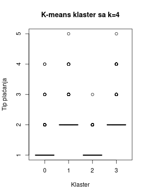

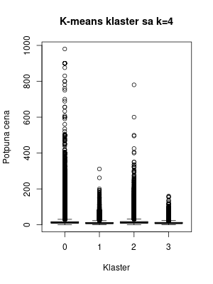

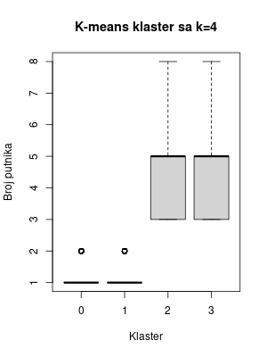

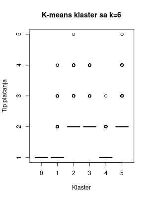

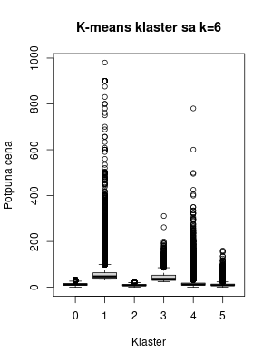

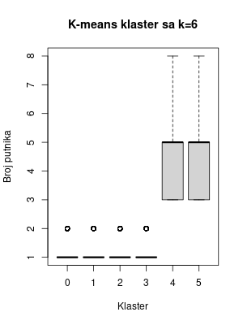

# Otkačivanje sa Spark sesije

```r
spark_disconnect(sc)
rm(list = ls())
```